# Model Building Weekend Homework

```r
library(tidyverse)
library(GGally)
library(ggfortify)
library(modelr)
```

```r
red_wine <- read_csv("data/wine_quality_red.csv")
white_wine <- read_csv("data/wine_quality_white.csv")
head(red_wine)
```

| wine_id | fixed_acidity | volatile_acidity | citric_acid | residual_sugar | chlorides | free_sulfur_dioxide | total_sulfur_dioxide | density | p_h | sulphates | alcohol | quality | region |
| --- | --- | --- | --- | --- | --- | --- | --- | --- | --- | --- | --- | --- | --- |
| 1 | 7.4 | 0.70 | 0.00 | 1.9 | 0.076 | 11 | 34 | 0.9978 | 3.51 | 0.56 | 9.4 | 4.66 | Australia |
| 2 | 7.8 | 0.88 | 0.00 | 2.6 | 0.098 | 25 | 67 | 0.9968 | 3.20 | 0.68 | 9.8 | 4.82 | Spain |
| 3 | 7.8 | 0.76 | 0.04 | 2.3 | 0.092 | 15 | 54 | 0.9970 | 3.26 | 0.65 | 9.8 | 4.91 | Spain |
| 4 | 11.2 | 0.28 | 0.56 | 1.9 | 0.075 | 17 | 60 | 0.9980 | 3.16 | 0.58 | 9.8 | 5.96 | Australia |
| 5 | 7.4 | 0.70 | 0.00 | 1.9 | 0.076 | 11 | 34 | 0.9978 | 3.51 | 0.56 | 9.4 | 5.42 | Italy |
| 6 | 7.4 | 0.66 | 0.00 | 1.8 | 0.075 | 13 | 40 | 0.9978 | 3.51 | 0.56 | 9.4 | 4.78 | Italy |

```r
head(white_wine)
```

| wine_id | fixed_acidity | volatile_acidity | citric_acid | residual_sugar | chlorides | free_sulfur_dioxide | total_sulfur_dioxide | density | p_h | sulphates | alcohol | quality | region |
| --- | --- | --- | --- | --- | --- | --- | --- | --- | --- | --- | --- | --- | --- |
| 1 | 7.0 | 0.27 | 0.36 | 20.7 | 0.045 | 45 | 170 | 1.0010 | 3.00 | 0.45 | 8.8 | 5.92 | Australia |
| 2 | 6.3 | 0.30 | 0.34 | 1.6 | 0.049 | 14 | 132 | 0.9940 | 3.30 | 0.49 | 9.5 | 6.06 | Australia |
| 3 | 8.1 | 0.28 | 0.40 | 6.9 | 0.050 | 30 | 97 | 0.9951 | 3.26 | 0.44 | 10.1 | 6.25 | Spain |
| 4 | 7.2 | 0.23 | 0.32 | 8.5 | 0.058 | 47 | 186 | 0.9956 | 3.19 | 0.40 | 9.9 | 6.38 | Spain |
| 5 | 7.2 | 0.23 | 0.32 | 8.5 | 0.058 | 47 | 186 | 0.9956 | 3.19 | 0.40 | 9.9 | 6.35 | USA |
| 6 | 8.1 | 0.28 | 0.40 | 6.9 | 0.050 | 30 | 97 | 0.9951 | 3.26 | 0.44 | 10.1 | 5.82 | Italy |

```r
# check for NA values
red_wine %>%
  filter(across(everything(), ~is.na(.)))
```

| wine_id | fixed_acidity | volatile_acidity | citric_acid | residual_sugar | chlorides | free_sulfur_dioxide | total_sulfur_dioxide | density | p_h | sulphates | alcohol | quality | region |
| --- | --- | --- | --- | --- | --- | --- | --- | --- | --- | --- | --- | --- | --- |

```r
white_wine %>%
  filter(across(everything(), ~is.na(.)))
```

| wine_id | fixed_acidity | volatile_acidity | citric_acid | residual_sugar | chlorides | free_sulfur_dioxide | total_sulfur_dioxide | density | p_h | sulphates | alcohol | quality | region |
| --- | --- | --- | --- | --- | --- | --- | --- | --- | --- | --- | --- | --- | --- |

```r
# change wine_id to be id_r for red wine and id_w for white wine
red_wine_clean <- red_wine %>%
  mutate(wine_id = paste0(wine_id,"_red"))

white_wine_clean <- white_wine %>%
  mutate(wine_id = paste0(wine_id,"_white"))
```

```r
# check col names are the same
colnames(white_wine_clean)
```

```
 [1] "wine_id"              "fixed_acidity"        "volatile_acidity"     "citric_acid"          "residual_sugar"       "chlorides"            "free_sulfur_dioxide"
 [8] "total_sulfur_dioxide" "density"              "p_h"                  "sulphates"            "alcohol"              "quality"              "region"
```

```r
colnames(red_wine_clean)
```

```
 [1] "wine_id"              "fixed_acidity"        "volatile_acidity"     "citric_acid"          "residual_sugar"       "chlorides"            "free_sulfur_dioxide"
 [8] "total_sulfur_dioxide" "density"              "p_h"                  "sulphates"            "alcohol"              "quality"              "region"
```

```r
# join data sets

(wine_full <- rbind(red_wine_clean, white_wine_clean))
```

| wine_id | fixed_acidity | volatile_acidity | citric_acid | residual_sugar | chlorides | free_sulfur_dioxide | total_sulfur_dioxide | density | p_h | sulphates | alcohol | quality | region |
| --- | --- | --- | --- | --- | --- | --- | --- | --- | --- | --- | --- | --- | --- |
| 1_red | 7.4 | 0.700 | 0.00 | 1.90 | 0.076 | 11.0 | 34 | 0.99780 | 3.51 | 0.56 | 9.4 | 4.66 | Australia |
| 2_red | 7.8 | 0.880 | 0.00 | 2.60 | 0.098 | 25.0 | 67 | 0.99680 | 3.20 | 0.68 | 9.8 | 4.82 | Spain |
| 3_red | 7.8 | 0.760 | 0.04 | 2.30 | 0.092 | 15.0 | 54 | 0.99700 | 3.26 | 0.65 | 9.8 | 4.91 | Spain |
| 4_red | 11.2 | 0.280 | 0.56 | 1.90 | 0.075 | 17.0 | 60 | 0.99800 | 3.16 | 0.58 | 9.8 | 5.96 | Australia |
| 5_red | 7.4 | 0.700 | 0.00 | 1.90 | 0.076 | 11.0 | 34 | 0.99780 | 3.51 | 0.56 | 9.4 | 5.42 | Italy |
| 6_red | 7.4 | 0.660 | 0.00 | 1.80 | 0.075 | 13.0 | 40 | 0.99780 | 3.51 | 0.56 | 9.4 | 4.78 | Italy |
| 7_red | 7.9 | 0.600 | 0.06 | 1.60 | 0.069 | 15.0 | 59 | 0.99640 | 3.30 | 0.46 | 9.4 | 5.09 | USA |
| 8_red | 7.3 | 0.650 | 0.00 | 1.20 | 0.065 | 15.0 | 21 | 0.99460 | 3.39 | 0.47 | 10.0 | 6.78 | Italy |
| 9_red | 7.8 | 0.580 | 0.02 | 2.00 | 0.073 | 9.0 | 18 | 0.99680 | 3.36 | 0.57 | 9.5 | 7.10 | USA |
| 10_red | 7.5 | 0.500 | 0.36 | 6.10 | 0.071 | 17.0 | 102 | 0.99780 | 3.35 | 0.80 | 10.5 | 4.78 | Australia |

[output cut: 990 more lines]

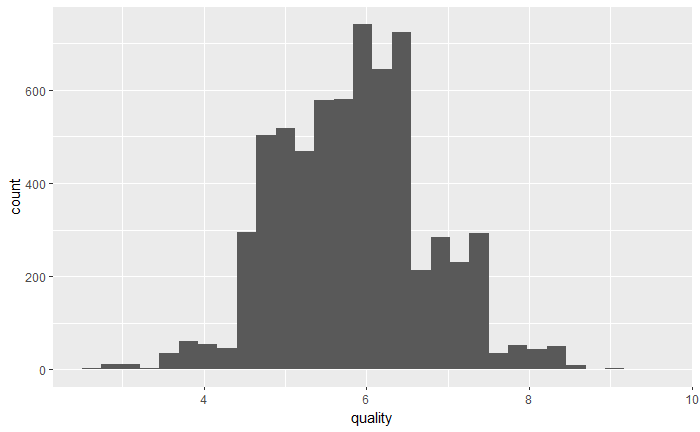

```r
wine_full %>%
  ggplot(aes(x = quality)) +
  geom_histogram()
```

data set looks fairly well distributed

data dictionary suggests that good predictors could be: volatile acidity (high = unpleasant) citric acid (high = fresher) residual sugar (high = sweet) chlorides (salt, assume high = bad?) total_sulfur_dioxide (low = oxidation and microbial growth (bad?))

at this point, could possibly also drop: density pH sulphates alcohol region as data dictionary does not provide any information on these variables having a distinct impact on taste, but will investigate data set first before committing to dropping these

to drop at this point: total_sulfur_dioxide is calculated from free_sulfur_dioxide, so it makes sense to drop free_sulfur_dioxide fixed_acidity seems like it would be related to pH, so drop that id column

[output not shown]

[output cut: 990 more lines]

citric acid column seems very low numbers from 0 - 1.66 group these into bins of:

< 0.5 0.5 - 1 1 - 1.5 > 1.5

```r
(wine_full_clean <- wine_full_clean %>%
  mutate(citric_acid = case_when(citric_acid < 0.50 ~ "<0.50",
                                    between(citric_acid, 0.50, 0.99) ~ "0.50 - 0.99",
                                    between(citric_acid, 1.00, 1.50) ~ "1.00 - 1.50",
                                    citric_acid > 1.50 ~ ">1.50"), .after = citric_acid
  ))
```

| volatile_acidity | citric_acid | residual_sugar | chlorides | total_sulfur_dioxide | density | p_h | sulphates | alcohol | quality | region |
| --- | --- | --- | --- | --- | --- | --- | --- | --- | --- | --- |
| 0.700 | <0.50 | 1.90 | 0.076 | 34 | 0.99780 | 3.51 | 0.56 | 9.4 | 4.66 | Australia |
| 0.880 | <0.50 | 2.60 | 0.098 | 67 | 0.99680 | 3.20 | 0.68 | 9.8 | 4.82 | Spain |
| 0.760 | <0.50 | 2.30 | 0.092 | 54 | 0.99700 | 3.26 | 0.65 | 9.8 | 4.91 | Spain |
| 0.280 | 0.50 - 0.99 | 1.90 | 0.075 | 60 | 0.99800 | 3.16 | 0.58 | 9.8 | 5.96 | Australia |
| 0.700 | <0.50 | 1.90 | 0.076 | 34 | 0.99780 | 3.51 | 0.56 | 9.4 | 5.42 | Italy |
| 0.660 | <0.50 | 1.80 | 0.075 | 40 | 0.99780 | 3.51 | 0.56 | 9.4 | 4.78 | Italy |
| 0.600 | <0.50 | 1.60 | 0.069 | 59 | 0.99640 | 3.30 | 0.46 | 9.4 | 5.09 | USA |
| 0.650 | <0.50 | 1.20 | 0.065 | 21 | 0.99460 | 3.39 | 0.47 | 10.0 | 6.78 | Italy |
| 0.580 | <0.50 | 2.00 | 0.073 | 18 | 0.99680 | 3.36 | 0.57 | 9.5 | 7.10 | USA |
| 0.500 | <0.50 | 6.10 | 0.071 | 102 | 0.99780 | 3.35 | 0.80 | 10.5 | 4.78 | Australia |

[output cut: 990 more lines]

```r
NA
```

alias check

```r
wine_sample <- wine_full_clean %>%
  slice_sample(prop = 0.1)
  alias(lm(quality ~ ., data = wine_sample))
```

```
Model :
quality ~ volatile_acidity + citric_acid + residual_sugar + chlorides +
    total_sulfur_dioxide + density + p_h + sulphates + alcohol +
    region
```

Looks like no predictors are colinear!

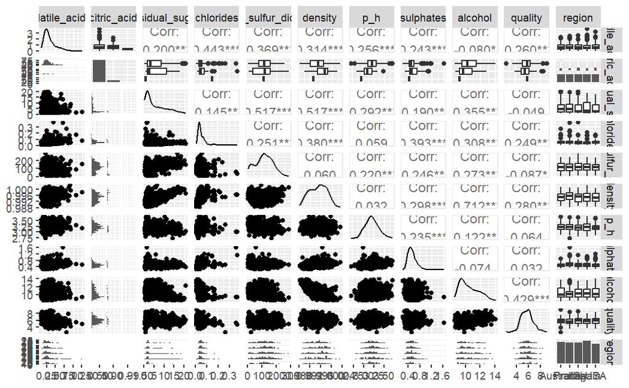

```r
wine_sample %>%
  ggpairs(progress = FALSE)
```

- It looks like the highest predictor of quality is alcohol content
- other predictors could be volatile acids, possibly citric acid?
- ph and sulphates have a lower correlation but could still be potential predictors
- region does not look like it provides much of an effect
- there is a high correlation between:
  - density and residual salt, which makes sense (why then do these not appear as colinear?)
  - chrlorides and volatile acids
  - alcohol and residual sugars
  - alcohol and density

Start with a SLR between quality and alcohol

```r
model_1a <- lm(quality ~ alcohol, data = wine_full_clean)
model_1b <- lm(quality ~ volatile_acidity, data = wine_full_clean)
model_1c <- lm(quality ~ citric_acid, data = wine_full_clean)
```

```r
summary(model_1a)
```

```
Call:
lm(formula = quality ~ alcohol, data = wine_full_clean)

Residuals:
    Min      1Q  Median      3Q     Max
-3.4852 -0.5552 -0.0293  0.5507  3.3362

Coefficients:
            Estimate Std. Error t value Pr(>|t|)
(Intercept) 2.362872   0.091794   25.74   <2e-16 ***
alcohol     0.331822   0.008693   38.17   <2e-16 ***
---
Signif. codes:  0 ‘***’ 0.001 ‘**’ 0.01 ‘*’ 0.05 ‘.’ 0.1 ‘ ’ 1

Residual standard error: 0.8357 on 6495 degrees of freedom
Multiple R-squared:  0.1832,    Adjusted R-squared:  0.1831
F-statistic:  1457 on 1 and 6495 DF,  p-value: < 2.2e-16
```

```r
summary(model_1b)
```

```
Call:
lm(formula = quality ~ volatile_acidity, data = wine_full_clean)

Residuals:
    Min      1Q  Median      3Q     Max
-3.4819 -0.6080 -0.0219  0.5345  3.4830

Coefficients:
                 Estimate Std. Error t value Pr(>|t|)
(Intercept)       6.32492    0.02545  248.48   <2e-16 ***
volatile_acidity -1.41503    0.06744  -20.98   <2e-16 ***
---
Signif. codes:  0 ‘***’ 0.001 ‘**’ 0.01 ‘*’ 0.05 ‘.’ 0.1 ‘ ’ 1

Residual standard error: 0.8948 on 6495 degrees of freedom
Multiple R-squared:  0.06349,   Adjusted R-squared:  0.06334
F-statistic: 440.3 on 1 and 6495 DF,  p-value: < 2.2e-16
```

```r
summary(model_1c)
```

```
Call:
lm(formula = quality ~ citric_acid, data = wine_full_clean)

Residuals:
   Min     1Q Median     3Q    Max
 -3.33  -0.69   0.00   0.55   3.58

Coefficients:
                       Estimate Std. Error t value Pr(>|t|)
(Intercept)             5.85995    0.01198 489.039  < 2e-16 ***
citric_acid>1.50        0.33005    0.92344   0.357    0.721
citric_acid0.50 - 0.99 -0.18173    0.04112  -4.419 1.01e-05 ***
citric_acid1.00 - 1.50 -0.29281    0.34920  -0.839    0.402
---
Signif. codes:  0 ‘***’ 0.001 ‘**’ 0.01 ‘*’ 0.05 ‘.’ 0.1 ‘ ’ 1

Residual standard error: 0.9234 on 6493 degrees of freedom
Multiple R-squared:  0.003117,  Adjusted R-squared:  0.002657
F-statistic: 6.768 on 3 and 6493 DF,  p-value: 0.000149
```

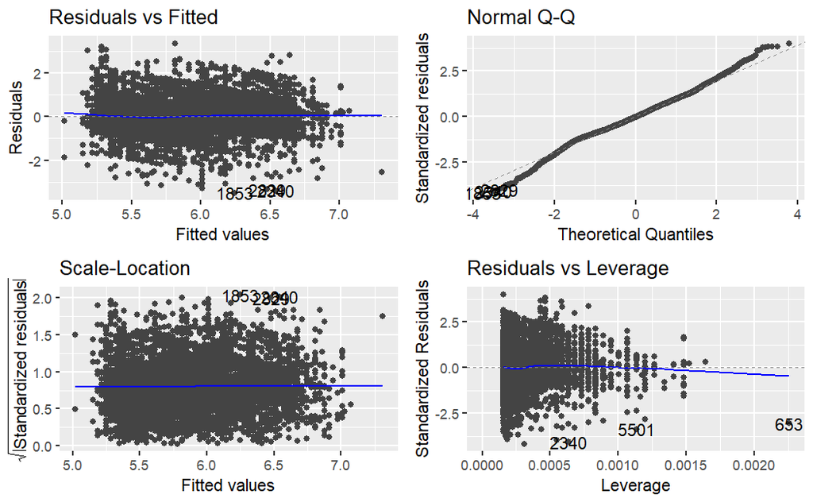

```r
autoplot(model_1a)
```

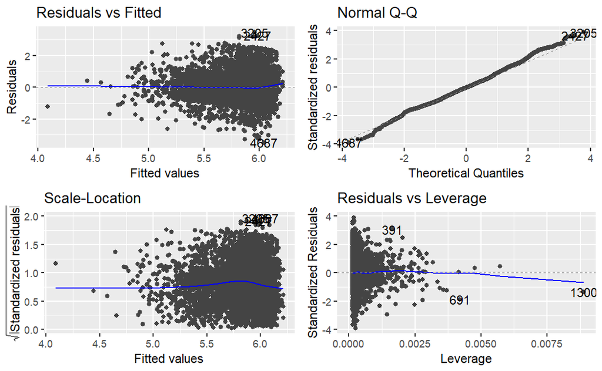

```r
autoplot(model_1b)
```

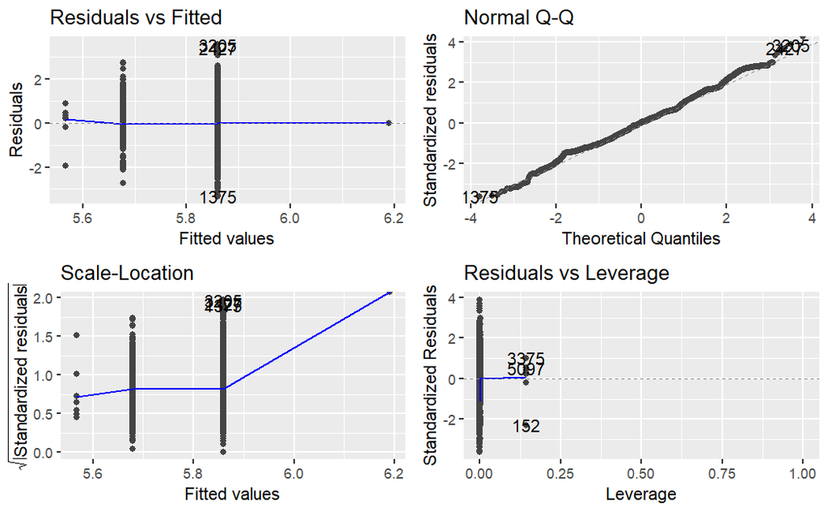

```r
autoplot(model_1c)
```

model 1a: Residuals vs fitted: appears to be randomly scattered around 0 Normal QQ: relatively flat along line with some distance at tails Scale-Location: no evidence of heteroskedacitity

model 1b: positively skewed check if improves when using log(volatile acidity)

model1c: all plots seem fine

```r
model_1b_log <- lm(quality ~ log(volatile_acidity), data = wine_full_clean)
summary(model_1b_log)
```

```
Call:
lm(formula = quality ~ log(volatile_acidity), data = wine_full_clean)

Residuals:
    Min      1Q  Median      3Q     Max
-3.5115 -0.6158 -0.0310  0.5474  3.5074

Coefficients:
                      Estimate Std. Error t value Pr(>|t|)
(Intercept)            5.21945    0.03185  163.88   <2e-16 ***
log(volatile_acidity) -0.52938    0.02529  -20.93   <2e-16 ***
---
Signif. codes:  0 ‘***’ 0.001 ‘**’ 0.01 ‘*’ 0.05 ‘.’ 0.1 ‘ ’ 1

Residual standard error: 0.895 on 6495 degrees of freedom
Multiple R-squared:  0.06319,   Adjusted R-squared:  0.06305
F-statistic: 438.1 on 1 and 6495 DF,  p-value: < 2.2e-16
```

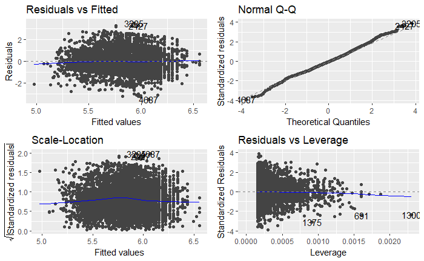

```r
autoplot(model_1b_log)
```

This does appear to fix the problem

quality ~ alcohol (model_1a) does appear to have the highest r squared value, so this will be the first predictor

Second predictor:

```r
(wine_resid <- wine_full_clean %>%
  add_residuals(model = model_1a, var = "resid") %>%
  select(-quality, -alcohol))
```

| volatile_acidity | citric_acid | residual_sugar | chlorides | total_sulfur_dioxide | density | p_h | sulphates | region | resid |
| --- | --- | --- | --- | --- | --- | --- | --- | --- | --- |
| 0.700 | <0.50 | 1.90 | 0.076 | 34 | 0.99780 | 3.51 | 0.56 | Australia | -0.821994305 |
| 0.880 | <0.50 | 2.60 | 0.098 | 67 | 0.99680 | 3.20 | 0.68 | Spain | -0.794722929 |
| 0.760 | <0.50 | 2.30 | 0.092 | 54 | 0.99700 | 3.26 | 0.65 | Spain | -0.704722929 |
| 0.280 | 0.50 - 0.99 | 1.90 | 0.075 | 60 | 0.99800 | 3.16 | 0.58 | Australia | 0.345277071 |
| 0.700 | <0.50 | 1.90 | 0.076 | 34 | 0.99780 | 3.51 | 0.56 | Italy | -0.061994305 |
| 0.660 | <0.50 | 1.80 | 0.075 | 40 | 0.99780 | 3.51 | 0.56 | Italy | -0.701994305 |
| 0.600 | <0.50 | 1.60 | 0.069 | 59 | 0.99640 | 3.30 | 0.46 | USA | -0.391994305 |
| 0.650 | <0.50 | 1.20 | 0.065 | 21 | 0.99460 | 3.39 | 0.47 | Italy | 1.098912760 |
| 0.580 | <0.50 | 2.00 | 0.073 | 18 | 0.99680 | 3.36 | 0.57 | USA | 1.584823539 |
| 0.500 | <0.50 | 6.10 | 0.071 | 102 | 0.99780 | 3.35 | 0.80 | Australia | -1.066998020 |

[output cut: 990 more lines]

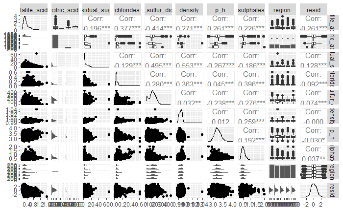

```r
wine_resid %>%
  ggpairs(progress = FALSE)
```

Residual sugars and total_sulfur_dioxide, and sulphates have a correlation with the residuals, investigate adding these residuals are nicely distributed

```r
model_2a <- lm(quality ~ alcohol + residual_sugar, data = wine_full_clean)
model_2b <- lm(quality ~ alcohol + total_sulfur_dioxide, data = wine_full_clean)
model_2c <- lm(quality ~ alcohol + sulphates, data = wine_full_clean)
```

```r
summary(model_2a)
```

```
Call:
lm(formula = quality ~ alcohol + residual_sugar, data = wine_full_clean)

Residuals:
    Min      1Q  Median      3Q     Max
-3.4797 -0.5469 -0.0265  0.5340  3.3382

Coefficients:
               Estimate Std. Error t value Pr(>|t|)
(Intercept)    1.834135   0.102542   17.89   <2e-16 ***
alcohol        0.368826   0.009228   39.97   <2e-16 ***
residual_sugar 0.025810   0.002313   11.16   <2e-16 ***
---
Signif. codes:  0 ‘***’ 0.001 ‘**’ 0.01 ‘*’ 0.05 ‘.’ 0.1 ‘ ’ 1

Residual standard error: 0.8278 on 6494 degrees of freedom
Multiple R-squared:  0.1986,    Adjusted R-squared:  0.1983
F-statistic: 804.6 on 2 and 6494 DF,  p-value: < 2.2e-16
```

```r
summary(model_2b)
```

```
Call:
lm(formula = quality ~ alcohol + total_sulfur_dioxide, data = wine_full_clean)

Residuals:
    Min      1Q  Median      3Q     Max
-3.4952 -0.5549 -0.0293  0.5462  3.3278

Coefficients:
                      Estimate Std. Error t value Pr(>|t|)
(Intercept)          2.0700359  0.1029030  20.116  < 2e-16 ***
alcohol              0.3466993  0.0089912  38.560  < 2e-16 ***
total_sulfur_dioxide 0.0011814  0.0001897   6.227 5.06e-10 ***
---
Signif. codes:  0 ‘***’ 0.001 ‘**’ 0.01 ‘*’ 0.05 ‘.’ 0.1 ‘ ’ 1

Residual standard error: 0.8332 on 6494 degrees of freedom
Multiple R-squared:  0.1881,    Adjusted R-squared:  0.1878
F-statistic: 752.1 on 2 and 6494 DF,  p-value: < 2.2e-16
```

```r
summary(model_2c)
```

```
Call:
lm(formula = quality ~ alcohol + sulphates, data = wine_full_clean)

Residuals:
    Min      1Q  Median      3Q     Max
-3.4645 -0.5498 -0.0268  0.5479  3.3508

Coefficients:
            Estimate Std. Error t value Pr(>|t|)
(Intercept) 2.253001   0.099022  22.753  < 2e-16 ***
alcohol     0.331899   0.008688  38.202  < 2e-16 ***
sulphates   0.205276   0.069636   2.948  0.00321 **
---
Signif. codes:  0 ‘***’ 0.001 ‘**’ 0.01 ‘*’ 0.05 ‘.’ 0.1 ‘ ’ 1

Residual standard error: 0.8352 on 6494 degrees of freedom
Multiple R-squared:  0.1843,    Adjusted R-squared:  0.1841
F-statistic: 733.7 on 2 and 6494 DF,  p-value: < 2.2e-16
```

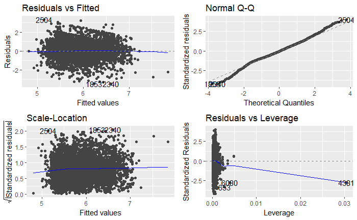

```r
autoplot(model_2a)
```

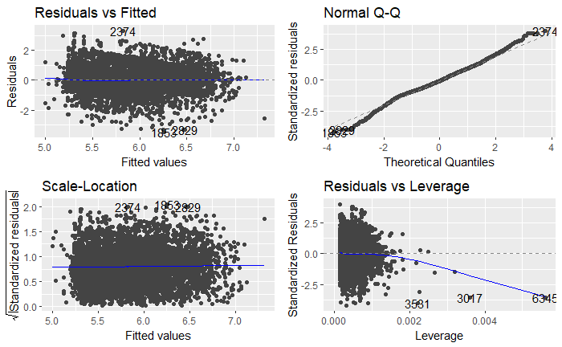

```r
autoplot(model_2b)
```

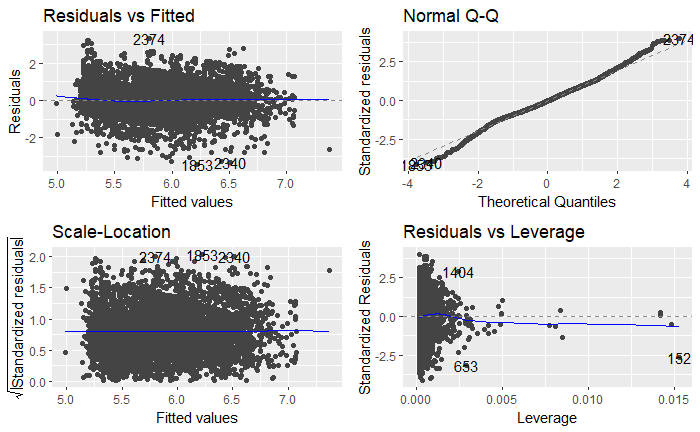

```r
autoplot(model_2c)
```

- all graphs appear ok
- residual sugar gave the highest r.sq value (model_2a), and improved the r.sq of the SLR(0.1832) so will use this as second predictor

does adding a third predictor help?

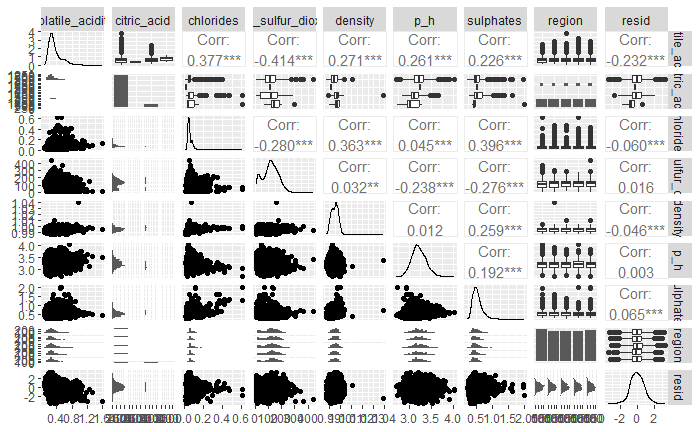

```r
wine_resid_2 <- wine_full_clean %>%
  add_residuals(model_2a, var = "resid") %>%
  select(-quality, - alcohol, -residual_sugar)

wine_resid_2 %>%
  ggpairs(progress = FALSE)
```

```r
model_3a <- lm(quality ~ alcohol + residual_sugar + sulphates, data = wine_full_clean)

summary(model_3a)
```

```
Call:
lm(formula = quality ~ alcohol + residual_sugar + sulphates,
    data = wine_full_clean)

Residuals:
    Min      1Q  Median      3Q     Max
-3.4414 -0.5456 -0.0256  0.5287  3.3752

Coefficients:
               Estimate Std. Error t value Pr(>|t|)
(Intercept)    1.582055   0.112731  14.034  < 2e-16 ***
alcohol        0.372576   0.009236  40.341  < 2e-16 ***
residual_sugar 0.028327   0.002356  12.021  < 2e-16 ***
sulphates      0.374656   0.070306   5.329 1.02e-07 ***
---
Signif. codes:  0 ‘***’ 0.001 ‘**’ 0.01 ‘*’ 0.05 ‘.’ 0.1 ‘ ’ 1

Residual standard error: 0.8261 on 6493 degrees of freedom
Multiple R-squared:  0.2021,    Adjusted R-squared:  0.2017
F-statistic: 548.1 on 3 and 6493 DF,  p-value: < 2.2e-16
```

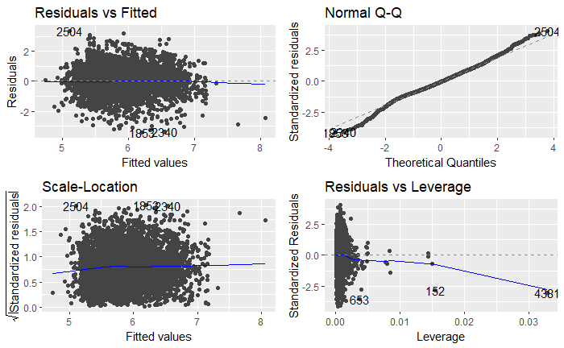

```r
autoplot(model_3a)
```

plots look ok r squared value has improved from before (0.1986 in previous model), RSE very slightly reduced, p Value is low for all predictors. Therefore would say that the best model for prediction is model_3a:

quality ~ alcohol + residual_sugar + sulphates

y = 1.582 + (alcohol * 0.372) + (residual_sugar * 0.028) + (sulphates * 0375)